# Developing an AI application

Going forward, AI algorithms will be incorporated into more and more everyday applications. For example, you might want to include an image classifier in a smart phone app. To do this, you'd use a deep learning model trained on hundreds of thousands of images as part of the overall application architecture. A large part of software development in the future will be using these types of models as common parts of applications.

In this project, you'll train an image classifier to recognize different species of flowers. You can imagine using something like this in a phone app that tells you the name of the flower your camera is looking at. In practice you'd train this classifier, then export it for use in your application. We'll be using [this dataset](http://www.robots.ox.ac.uk/~vgg/data/flowers/102/index.html) of 102 flower categories, you can see a few examples below.

[figure not shown]

The project is broken down into multiple steps:

- Load and preprocess the image dataset
- Train the image classifier on your dataset
- Use the trained classifier to predict image content

We'll lead you through each part which you'll implement in Python.

When you've completed this project, you'll have an application that can be trained on any set of labeled images. Here your network will be learning about flowers and end up as a command line application. But, what you do with your new skills depends on your imagination and effort in building a dataset. For example, imagine an app where you take a picture of a car, it tells you what the make and model is, then looks up information about it. Go build your own dataset and make something new.

First up is importing the packages you'll need. It's good practice to keep all the imports at the beginning of your code. As you work through this notebook and find you need to import a package, make sure to add the import up here.

```python
# Necessary packages and modules
%matplotlib inline
%config InlineBackend.figure_format = 'retina'

import numpy as np
import matplotlib.pyplot as plt
import torch
import torchvision
from torchvision import datasets, transforms, utils, models
from torch import nn
from torch import optim
import torch.nn.functional as F
from torch.optim import lr_scheduler

import os
from textwrap import wrap
from collections import OrderedDict
import time
import copy
from PIL import Image
```

## Load the data

Here you'll use `torchvision` to load the data ([documentation](http://pytorch.org/docs/0.3.0/torchvision/index.html)). The data should be included alongside this notebook, otherwise you can [download it here](https://s3.amazonaws.com/content.udacity-data.com/nd089/flower_data.tar.gz). The dataset is split into three parts, training, validation, and testing. For the training, you'll want to apply transformations such as random scaling, cropping, and flipping. This will help the network generalize leading to better performance. You'll also need to make sure the input data is resized to 224x224 pixels as required by the pre-trained networks.

The validation and testing sets are used to measure the model's performance on data it hasn't seen yet. For this you don't want any scaling or rotation transformations, but you'll need to resize then crop the images to the appropriate size.

The pre-trained networks you'll use were trained on the ImageNet dataset where each color channel was normalized separately. For all three sets you'll need to normalize the means and standard deviations of the images to what the network expects. For the means, it's `[0.485, 0.456, 0.406]` and for the standard deviations `[0.229, 0.224, 0.225]`, calculated from the ImageNet images. These values will shift each color channel to be centered at 0 and range from -1 to 1.

```python
data_dir = 'flowers'
```

```python
# Torchvision transforms used to augment the training data with random scaling, rotations, mirroring and cropping
# The training, validation and testing data appropriately cropped and normalized
# The data for each set is loaded with torchvision's DataLoader
# The data for each set (train, validation, test) is loaded with torchvision's ImageFolder

normalize = transforms.Normalize(mean = [0.485, 0.456, 0.406], std=[0.229, 0.224, 0.225])
data_transforms = {
    'train': transforms.Compose([
        transforms.RandomRotation(30),
        transforms.RandomResizedCrop(224),
        transforms.RandomHorizontalFlip(),
        transforms.ToTensor(),
        normalize
    ]),
    'test': transforms.Compose([
        transforms.Resize(256),
        transforms.CenterCrop(224),
        transforms.ToTensor(),
        normalize
    ]),
    'valid': transforms.Compose([
        transforms.Resize(256),
        transforms.CenterCrop(224),
        transforms.ToTensor(),
        normalize
    ]),
}

image_datasets = {x: datasets.ImageFolder(os.path.join(data_dir, x),
                                          data_transforms[x])
                  for x in ['train', 'test', 'valid']}

dataset_sizes = {x: len(image_datasets[x])
                              for x in ['train', 'test', 'valid']}

dataloaders = {x: torch.utils.data.DataLoader(image_datasets[x], batch_size=64,
                                             shuffle=True)
              for x in ['train', 'test', 'valid']}
```

### Label mapping

You'll also need to load in a mapping from category label to category name. You can find this in the file `cat_to_name.json`. It's a JSON object which you can read in with the [`json` module](https://docs.python.org/2/library/json.html). This will give you a dictionary mapping the integer encoded categories to the actual names of the flowers.

```python
import json

with open('cat_to_name.json', 'r') as f:
    cat_to_name = json.load(f)
```

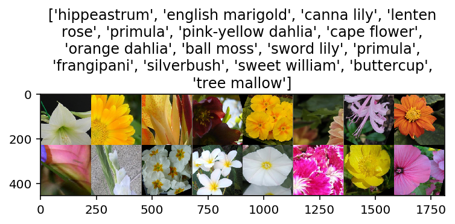

```python
# Visualizing a few training images so as to understand the data augmentations

def initial_imshow(inp, title=None):
    inp = inp.numpy().transpose((1, 2, 0))
    # unnormalizing
    mean = np.array([0.485, 0.456, 0.406])
    std = np.array([0.229, 0.224, 0.225])
    inp = std * inp + mean
    inp = np.clip(inp, 0, 1)
    plt.imshow(inp)
    if title is not None:
        plt.title('\n'.join(wrap(title, 60)))
    plt.pause(0.001)

(inputs, classes) = next(iter(dataloaders['train']))
# Lets only show 16 images for visibility
(inputs, classes) = inputs[0:16], classes[0:16]
out = torchvision.utils.make_grid(inputs)
class_names = image_datasets['train'].classes
initial_imshow(out, title=str([cat_to_name.get(class_names[x]) for x in
       classes]))
```

# Building and training the classifier

Now that the data is ready, it's time to build and train the classifier. As usual, you should use one of the pretrained models from `torchvision.models` to get the image features. Build and train a new feed-forward classifier using those features.

We're going to leave this part up to you. If you want to talk through it with someone, chat with your fellow students! You can also ask questions on the forums or join the instructors in office hours.

Refer to [the rubric](https://review.udacity.com/#!/rubrics/1663/view) for guidance on successfully completing this section. Things you'll need to do:

- Load a [pre-trained network](http://pytorch.org/docs/master/torchvision/models.html) (If you need a starting point, the VGG networks work great and are straightforward to use)
- Define a new, untrained feed-forward network as a classifier, using ReLU activations and dropout
- Train the classifier layers using backpropagation using the pre-trained network to get the features
- Track the loss and accuracy on the validation set to determine the best hyperparameters

We've left a cell open for you below, but use as many as you need. Our advice is to break the problem up into smaller parts you can run separately. Check that each part is doing what you expect, then move on to the next. You'll likely find that as you work through each part, you'll need to go back and modify your previous code. This is totally normal!

When training make sure you're updating only the weights of the feed-forward network. You should be able to get the validation accuracy above 70% if you build everything right. Make sure to try different hyperparameters (learning rate, units in the classifier, epochs, etc) to find the best model. Save those hyperparameters to use as default values in the next part of the project.

```python
# Loading the VGG (pretrained network) from torchvision.models
model = models.vgg19(pretrained=True)
```

```
Downloading: "https://download.pytorch.org/models/vgg19-dcbb9e9d.pth" to /root/.torch/models/vgg19-dcbb9e9d.pth
```

```python
# pretrained model classifier
model.classifier
```

```
Sequential(
  (0): Linear(in_features=25088, out_features=4096, bias=True)
  (1): ReLU(inplace)
  (2): Dropout(p=0.5)
  (3): Linear(in_features=4096, out_features=4096, bias=True)
  (4): ReLU(inplace)
  (5): Dropout(p=0.5)
  (6): Linear(in_features=4096, out_features=1000, bias=True)
)
```

```python
# freezing the model parameters
for param in model.parameters():
    param.requires_grad = False
```

```python
# out input_size matches the in_features of pretrained model
input_size = 25088
output_size = len(class_names)
```

```python
output_size
```

```
102
```

```python
# creating the classifier ordered dictionary first
# will be using this to save the model
classifier_dict = OrderedDict([
    ('fc1', nn.Linear(input_size, 1024)),
    ('relu1', nn.ReLU()),
    ('dropout1', nn.Dropout(p=0.2)),
    ('fc2', nn.Linear(1024, 512)),
    ('relu2', nn.ReLU()),
    ('dropout2', nn.Dropout(p=0.2)),
    ('fc3', nn.Linear(512, output_size)),
    ('output', nn.LogSoftmax(dim=1)),
    ])
```

```python
# creating the classifier for our usage using the ordered dictionary
classifier = nn.Sequential(classifier_dict)
```

```python
# replacing the pretrained model classifier with our classifier
model.classifier = classifier
```

```python
# defining the criterion and optimizer

# NLLLoss because our output is LogSoftmax
criterion = nn.NLLLoss()

# Adam optimizer with a learning rate
optimizer = optim.Adam(model.classifier.parameters(), lr = 0.001)

# Decay LR by a factor of 0.1 every 5 epochs
exp_lr_scheduler = lr_scheduler.StepLR(optimizer, step_size=5, gamma=0.1)
```

```python
# creating a cuda boolean for availability of cuda
cuda = torch.cuda.is_available()
```

```python
cuda
```

```
True
```

```python
# Calculate the accuracy of the model
def calc_accuracy(model, data, cuda):
    accuracy_list = []
    if (cuda):
        model.cuda()
    model.eval()
    with torch.no_grad():
        for idx, (inputs, labels) in enumerate(dataloaders[data]):
            if cuda:
                inputs, labels = inputs.cuda(), labels.cuda()
            outputs = model.forward(inputs)
            _, predicted = outputs.max(dim=1)
            print ('\nBatch no ----- ', idx+1)
            print('Predicted Class: ', predicted)
            print('Probability: ', torch.exp(_))
            equals = predicted == labels.data
            print('Correctly predicted: ', equals)
            batch_accuracy = equals.float().mean().item()
            accuracy_list.append(batch_accuracy)
            print('Batch accuracy: ',batch_accuracy)
        print('\n Mean accuracy: ', np.mean(accuracy_list))
```

```python
# calculating the accuracy of the model on test data before training
calc_accuracy(model, 'test', cuda)
```

[output not shown]

[output cut: 268 more lines]

```
       [ 1.2861,  1.1711,  1.2276,  1.2149,  1.3308,  1.2389,  1.2455,
         1.5867,  1.2908,  1.1753,  1.2715,  1.2164,  1.3189,  1.3192,
         1.2290,  1.2845,  1.2327,  1.1653,  1.2063,  1.2422,  1.3059,
         1.2151,  1.2323,  1.2421,  1.1833,  1.2180,  1.1561,  1.3289,
         1.3419,  1.2468,  1.1854,  1.1646,  1.1673,  1.1647,  1.3053,
         1.1602,  1.4193,  1.3033,  1.2798,  1.1315,  1.2430,  1.2910,
         1.2262,  1.1990,  1.2276,  1.5256,  1.2278,  1.2427,  1.2367,
         1.2789,  1.2702], device='cuda:0')
Correctly predicted:  tensor([ 0,  0,  0,  0,  0,  0,  0,  0,  0,  0,  0,  0,  0,  0,
         0,  0,  0,  0,  0,  0,  0,  0,  0,  0,  0,  0,  0,  0,
         0,  0,  0,  0,  0,  0,  0,  0,  0,  0,  0,  0,  0,  0,
         0,  0,  0,  0,  0,  0,  0,  0,  0], dtype=torch.uint8, device='cuda:0')
Batch accuracy:  0.0

 Mean accuracy:  0.00600961538462
```

```python
# Training the model
# Validation loss and accuracy are displayed
def train_model(model, criterion, optimizer, scheduler, num_epochs, cuda):
    since = time.time()

    best_model_wts = copy.deepcopy(model.state_dict())
    best_acc = 0.0

    if (cuda):
        model.cuda()

    for epoch in range(num_epochs):
        print('Epoch {}/{}'.format(epoch, num_epochs - 1))
        print('-' * 10)

        # Each epoch has a training and validation phase
        for phase in ['train', 'valid']:
            if phase == 'train':
                scheduler.step()
                model.train()  # Set model to training mode
            else:
                model.eval()   # Set model to evaluate mode

            running_loss = 0.0
            running_corrects = 0

            # Iterate over data.
            for inputs, labels in dataloaders[phase]:
                if (cuda):
                    inputs = inputs.cuda()
                    labels = labels.cuda()

                # zero the parameter gradients
                optimizer.zero_grad()

                # forward
                # track history if only in train
                with torch.set_grad_enabled(phase == 'train'):
                    outputs = model(inputs)
                    _, preds = torch.max(outputs, 1)
                    loss = criterion(outputs, labels)

                    # backward + optimize only if in training phase
                    if phase == 'train':
                        loss.backward()
                        optimizer.step()

                # statistics
                running_loss += loss.item() * inputs.size(0)
                running_corrects += torch.sum(preds == labels.data)

            epoch_loss = running_loss / dataset_sizes[phase]
            epoch_acc = running_corrects.double() / dataset_sizes[phase]

            print('{} Loss: {:.4f} Acc: {:.4f}'.format(
                phase, epoch_loss, epoch_acc))

            # deep copy the model
            if phase == 'valid' and epoch_acc > best_acc:
                best_acc = epoch_acc
                best_model_wts = copy.deepcopy(model.state_dict())

        print()

    time_elapsed = time.time() - since
    print('Training complete in {:.0f}m {:.0f}s'.format(
        time_elapsed // 60, time_elapsed % 60))
    print('Best val Acc: {:4f}'.format(best_acc))

    # load best model weights
    model.load_state_dict(best_model_wts)
    return model
```

```python
# training the model
trained_model = train_model(model, criterion, optimizer, exp_lr_scheduler, 10, cuda)
```

```
----------
train Loss: 2.8666 Acc: 0.3317
valid Loss: 1.2009 Acc: 0.6650

----------
train Loss: 1.4591 Acc: 0.6006
valid Loss: 0.7689 Acc: 0.7775

----------
train Loss: 1.2247 Acc: 0.6690
valid Loss: 0.6490 Acc: 0.8105

----------
train Loss: 1.0662 Acc: 0.7036
valid Loss: 0.5562 Acc: 0.8435

----------
train Loss: 0.9635 Acc: 0.7332
valid Loss: 0.4913 Acc: 0.8509

----------
train Loss: 0.7766 Acc: 0.7813
valid Loss: 0.3783 Acc: 0.8888

----------
train Loss: 0.6754 Acc: 0.8114
valid Loss: 0.3545 Acc: 0.8936

----------
train Loss: 0.6623 Acc: 0.8133
valid Loss: 0.3469 Acc: 0.9046

----------
train Loss: 0.6382 Acc: 0.8222
valid Loss: 0.3377 Acc: 0.9071

----------
train Loss: 0.6064 Acc: 0.8274
valid Loss: 0.3438 Acc: 0.9095

Training complete in 28m 52s
Best val Acc: 0.909535
```

## Testing your network

It's good practice to test your trained network on test data, images the network has never seen either in training or validation. This will give you a good estimate for the model's performance on completely new images. Run the test images through the network and measure the accuracy, the same way you did validation. You should be able to reach around 70% accuracy on the test set if the model has been trained well.

```python
# calculating the accuracy of the model on test data after training
calc_accuracy(trained_model, 'test', cuda)
```

[output not shown]

[output cut: 263 more lines]

```
Probability:  tensor([ 1.0000,  1.0000,  0.9994,  1.0000,  0.9875,  1.0000,  1.0000,
         1.0000,  0.9948,  0.9612,  0.9501,  0.9868,  1.0000,  0.7912,
         0.7281,  0.9210,  1.0000,  1.0000,  1.0000,  0.9249,  0.9679,
         1.0000,  0.9862,  1.0000,  0.9994,  0.9999,  1.0000,  1.0000,
         1.0000,  1.0000,  0.9999,  1.0000,  0.9977,  0.3812,  1.0000,
         0.5558,  1.0000,  1.0000,  0.7445,  0.8969,  1.0000,  0.8846,
         1.0000,  0.5523,  0.8183,  0.9163,  0.9415,  0.4461,  0.9959,
         1.0000,  0.9435], device='cuda:0')
Correctly predicted:  tensor([ 1,  1,  1,  1,  1,  1,  1,  1,  1,  1,  1,  1,  1,  1,
         1,  1,  1,  1,  1,  1,  1,  1,  1,  1,  1,  1,  1,  1,
         1,  1,  1,  1,  1,  0,  1,  0,  1,  1,  1,  0,  1,  1,
         1,  0,  1,  0,  1,  1,  1,  1,  1], dtype=torch.uint8, device='cuda:0')
Batch accuracy:  0.9019607901573181

 Mean accuracy:  0.873468137704
```

## Save the checkpoint

Now that your network is trained, save the model so you can load it later for making predictions. You probably want to save other things such as the mapping of classes to indices which you get from one of the image datasets: `image_datasets['train'].class_to_idx`. You can attach this to the model as an attribute which makes inference easier later on.

`model.class_to_idx = image_datasets['train'].class_to_idx`

Remember that you'll want to completely rebuild the model later so you can use it for inference. Make sure to include any information you need in the checkpoint. If you want to load the model and keep training, you'll want to save the number of epochs as well as the optimizer state, `optimizer.state_dict`. You'll likely want to use this trained model in the next part of the project, so best to save it now.

```python
# Saving the model, the classifier dictionary is also stored
trained_model.class_to_idx = image_datasets['train'].class_to_idx
torch.save({'arch': 'vgg19',
            'classifier_dict': classifier_dict,
            'state_dict': trained_model.state_dict(),
            'class_to_idx': trained_model.class_to_idx},
            'classifier.pth')
```

## Loading the checkpoint

At this point it's good to write a function that can load a checkpoint and rebuild the model. That way you can come back to this project and keep working on it without having to retrain the network.

```python
# Function that loads the model
def load_model(checkpoint_path):
    checkpoint = torch.load(checkpoint_path)
    model = models.vgg19(pretrained=True)
    for param in model.parameters():
        param.requires_grad = False
    model.class_to_idx = checkpoint['class_to_idx']
    model.classifier = nn.Sequential(checkpoint['classifier_dict'])
    model.load_state_dict(checkpoint['state_dict'])
    return model
```

```python
# Loading the model and calculating accuracy
loaded_model = load_model('classifier.pth')
calc_accuracy(loaded_model, 'test', cuda)
```

[output not shown]

[output cut: 259 more lines]

```
Probability:  tensor([ 0.9992,  0.9987,  0.6667,  0.9993,  0.9994,  1.0000,  0.7912,
         0.4575,  0.7923,  1.0000,  0.5600,  0.9993,  0.9936,  0.9994,
         0.9729,  1.0000,  0.9067,  1.0000,  1.0000,  0.9991,  0.9951,
         1.0000,  0.9818,  0.9573,  1.0000,  0.9672,  0.9998,  1.0000,
         0.9938,  0.7445,  0.5692,  1.0000,  0.9984,  0.9999,  0.9999,
         1.0000,  1.0000,  1.0000,  1.0000,  0.9866,  0.9996,  1.0000,
         0.7093,  1.0000,  0.9998,  0.8272,  0.9962,  0.9941,  0.5425,
         0.6842,  1.0000], device='cuda:0')
Correctly predicted:  tensor([ 1,  1,  0,  1,  1,  1,  1,  0,  1,  1,  1,  1,  1,  1,
         1,  1,  1,  1,  1,  1,  1,  1,  1,  1,  1,  1,  1,  1,
         1,  1,  0,  1,  1,  1,  1,  1,  1,  1,  1,  1,  1,  1,
         0,  1,  1,  1,  1,  1,  1,  1,  1], dtype=torch.uint8, device='cuda:0')
Batch accuracy:  0.9215686321258545

 Mean accuracy:  0.873774510164
```

# Inference for classification

Now you'll write a function to use a trained network for inference. That is, you'll pass an image into the network and predict the class of the flower in the image. Write a function called `predict` that takes an image and a model, then returns the top $K$ most likely classes along with the probabilities. It should look like

```
probs, classes = predict(image_path, model)
print(probs)
print(classes)
> [ 0.01558163  0.01541934  0.01452626  0.01443549  0.01407339]
> ['70', '3', '45', '62', '55']
```

First you'll need to handle processing the input image such that it can be used in your network.

## Image Preprocessing

You'll want to use `PIL` to load the image ([documentation](https://pillow.readthedocs.io/en/latest/reference/Image.html)). It's best to write a function that preprocesses the image so it can be used as input for the model. This function should process the images in the same manner used for training.

First, resize the images where the shortest side is 256 pixels, keeping the aspect ratio. This can be done with the [`thumbnail`](http://pillow.readthedocs.io/en/3.1.x/reference/Image.html#PIL.Image.Image.thumbnail) or [`resize`](http://pillow.readthedocs.io/en/3.1.x/reference/Image.html#PIL.Image.Image.thumbnail) methods. Then you'll need to crop out the center 224x224 portion of the image.

Color channels of images are typically encoded as integers 0-255, but the model expected floats 0-1. You'll need to convert the values. It's easiest with a Numpy array, which you can get from a PIL image like so `np_image = np.array(pil_image)`.

As before, the network expects the images to be normalized in a specific way. For the means, it's `[0.485, 0.456, 0.406]` and for the standard deviations `[0.229, 0.224, 0.225]`. You'll want to subtract the means from each color channel, then divide by the standard deviation.

And finally, PyTorch expects the color channel to be the first dimension but it's the third dimension in the PIL image and Numpy array. You can reorder dimensions using [`ndarray.transpose`](https://docs.scipy.org/doc/numpy-1.13.0/reference/generated/numpy.ndarray.transpose.html). The color channel needs to be first and retain the order of the other two dimensions.

```python
# Image preprocessing to convert pil image into an object tht can be used as input to a trained model
def image_preprocessing(image_path):
    im = Image.open(image_path)
    if (im.size[0] < im.size[1]):
        im.thumbnail((256, 10000), Image.ANTIALIAS)
    else:
        im.thumbnail((10000, 256), Image.ANTIALIAS)

    left =  (im.width-224)/2
    lower = (im.height-224)/2
    right = left+224
    upper = lower+224
    box = (left, lower, right, upper)
    im = im.crop(box)

    np_im = np.array(im)/225
    np_im = (np_im - np.array([0.485, 0.456, 0.406]))/np.array([0.229, 0.224, 0.225])
    np_im = np_im.transpose((2,0,1))
    return np_im
```

```python
# Testing the image_preprocessing
input_image1_path = os.path.join(data_dir, 'test/6/image_07173.jpg')
image_preprocessing(input_image1_path)
```

```
array([[[-0.58466764, -0.83697234, -0.99223678, ..., -0.40999515,
          0.01698205,  0.75448811],
        [-0.29354682, -0.46821931, -0.79815623, ...,  0.15283843,
          0.81271228,  1.02620087],
        [-0.08005822, -0.19650655, -0.56525958, ...,  0.75448811,
          1.02620087,  0.59922368],
        ...,
        [-0.87578845, -0.75934013, -0.62348375, ..., -1.55507035,
         -1.57447841, -1.55507035],
        [-1.16690927, -1.01164483, -0.73993207, ..., -1.59388646,
         -1.65211063, -1.63270257],
        [-1.26394954, -1.14750121, -0.95342067, ..., -1.76855895,
         -1.78796701, -1.71033479]],

       [[ 0.28571429,  0.08730159, -0.03174603, ..., -1.73809524,
         -1.14285714, -0.36904762],
        [ 0.44444444,  0.30555556,  0.04761905, ..., -1.24206349,
         -0.50793651, -0.25      ],
        [ 0.64285714,  0.56349206,  0.24603175, ..., -0.56746032,
         -0.21031746, -0.62698413],
        ...,
        [-0.82539683, -0.70634921, -0.54761905, ..., -1.44047619,
         -1.46031746, -1.44047619],
        [-1.04365079, -0.86507937, -0.58730159, ..., -1.51984127,
         -1.55952381, -1.53968254],
        [-1.16269841, -1.02380952, -0.82539683, ..., -1.67857143,
         -1.6984127 , -1.61904762]],

       [[-0.89580247, -1.13283951, -1.2908642 , ..., -1.76493827,
         -1.15259259, -0.40197531],
        [-0.63901235, -0.83654321, -1.15259259, ..., -1.35012346,
         -0.61925926, -0.34271605],
        [-0.4217284 , -0.59950617, -0.9945679 , ..., -0.67851852,
         -0.34271605, -0.71802469],
        ...,
        [-0.77728395, -0.71802469, -0.56      , ..., -1.27111111,
         -1.2908642 , -1.27111111],
        [-0.95506173, -0.79703704, -0.56      , ..., -1.31061728,
         -1.36987654, -1.35012346],
        [-1.05382716, -0.95506173, -0.77728395, ..., -1.48839506,
         -1.50814815, -1.4291358 ]]])
```

```python
# Function that plots preprocessed image
def imshow(image, ax=None, title=None):
    if ax is None:
        fig, ax = plt.subplots()
    if title:
        plt.title(title)
    image = image.transpose((1, 2, 0))

    mean = np.array([0.485, 0.456, 0.406])
    std = np.array([0.229, 0.224, 0.225])
    image = std * image + mean
    image = np.clip(image, 0, 1)
    ax.imshow(image)
    return ax
```

```python
# Function that plots the original image
def original_image(image_path, ax=None, title=None):
    image = Image.open(image_path)
    if ax is None:
        fig, ax = plt.subplots()
    if title:
        plt.title(title)
    ax.imshow(image)
    return ax
```

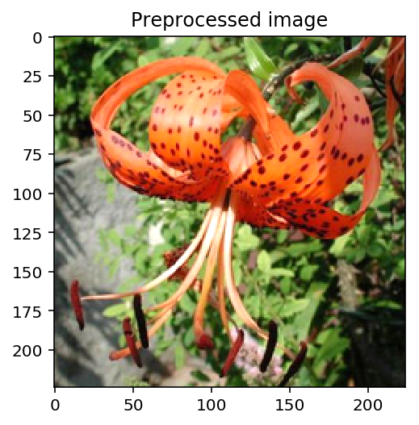

```python
# Testing the imshow function
imshow(image_preprocessing(input_image1_path), title='Preprocessed image')
```

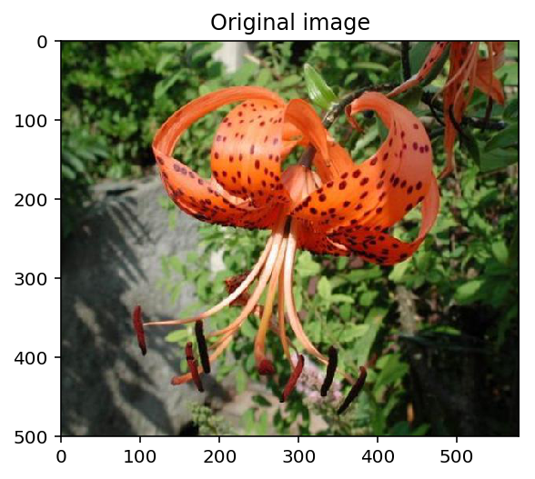

```python
# Testing the original_image function, also comparing with preprocessed image
original_image(input_image1_path, title='Original image')
```

## Class Prediction

Once you can get images in the correct format, it's time to write a function for making predictions with your model. A common practice is to predict the top 5 or so (usually called top-$K$) most probable classes. You'll want to calculate the class probabilities then find the $K$ largest values.

To get the top $K$ largest values in a tensor use [`x.topk(k)`](http://pytorch.org/docs/master/torch.html#torch.topk). This method returns both the highest `k` probabilities and the indices of those probabilities corresponding to the classes. You need to convert from these indices to the actual class labels using `class_to_idx` which hopefully you added to the model or from an `ImageFolder` you used to load the data (see here). Make sure to invert the dictionary so you get a mapping from index to class as well.

Again, this method should take a path to an image and a model checkpoint, then return the probabilities and classes.

```
probs, classes = predict(image_path, model)
print(probs)
print(classes)
> [ 0.01558163  0.01541934  0.01452626  0.01443549  0.01407339]
> ['70', '3', '45', '62', '55']
```

```python
# Predict function for top k features
def predict(image_path, model, topk, cuda):
    if (cuda):
        model = model.cpu()
    processed_image = image_preprocessing(image_path)
    processed_image_float = torch.from_numpy(processed_image).type(torch.FloatTensor)
    # adding batch size of 1
    processed_image_float.unsqueeze_(0)
    output = model.forward(processed_image_float)
    probability = torch.exp(output)
    probs, classes = probability.topk(topk)
    probs = probs.detach().numpy().tolist()[0]
    classes = classes.detach().numpy().tolist()[0]
    idx_to_class = {val: key for key, val in
                        model.class_to_idx.items()}
    labels = [cat_to_name[idx_to_class[label]] for label in classes]
    return probs, labels
```

```python
# Testing the predict function
predict(input_image1_path, loaded_model, 5, cuda)
```

```
([0.9999998807907104,
  5.1207383222617864e-08,
  4.255147345588739e-08,
  1.5919069396019836e-09,
  5.542369341249298e-10],
 ['tiger lily',
  'blackberry lily',
  'purple coneflower',
  'bird of paradise',
  'fire lily'])
```

## Sanity Checking

Now that you can use a trained model for predictions, check to make sure it makes sense. Even if the testing accuracy is high, it's always good to check that there aren't obvious bugs. Use `matplotlib` to plot the probabilities for the top 5 classes as a bar graph, along with the input image. It should look like this:

[figure not shown]

You can convert from the class integer encoding to actual flower names with the `cat_to_name.json` file (should have been loaded earlier in the notebook). To show a PyTorch tensor as an image, use the `imshow` function defined above.

```python
# Function that plots top k probabilities associated with input
def plot_topk(image_path, model):
    plt.figure(figsize = (6,10))
    ax = plt.subplot(2,1,1)
    title = 'Input'
    original_image(image_path, ax=ax, title=title)
    probs, labels = predict(image_path, model, 5, cuda)
    plt.subplot(2,1,2)
    plt.barh(labels, probs, align='center', alpha=0.5)
    plt.show()
```

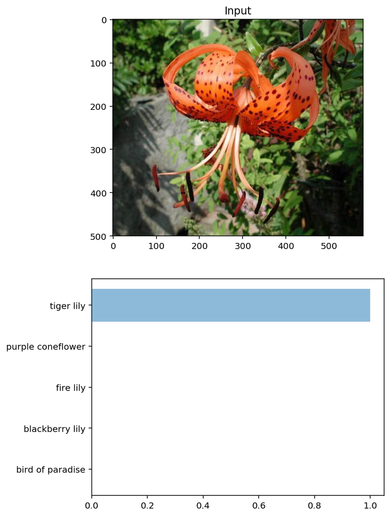

```python
# Testing the plot_topk function
plot_topk(input_image1_path, loaded_model)
```

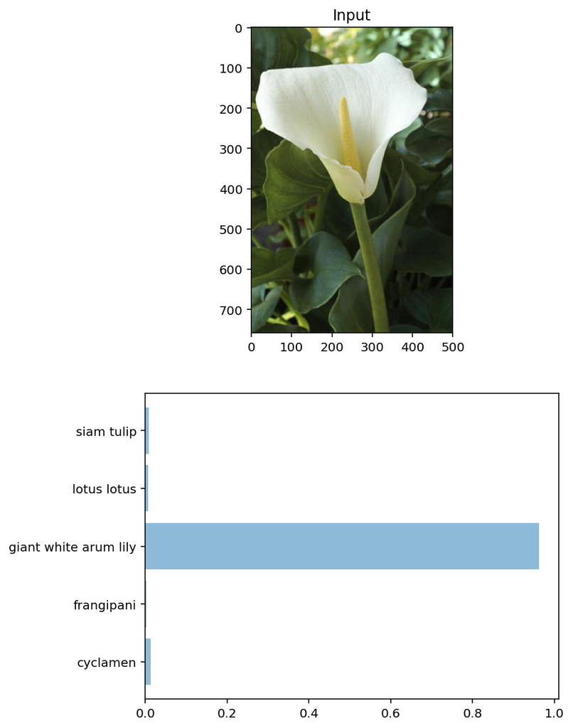

```python
# More testing
input_image2_path = os.path.join(data_dir, 'test/20/image_04910.jpg')
plot_topk(input_image2_path, loaded_model)
```

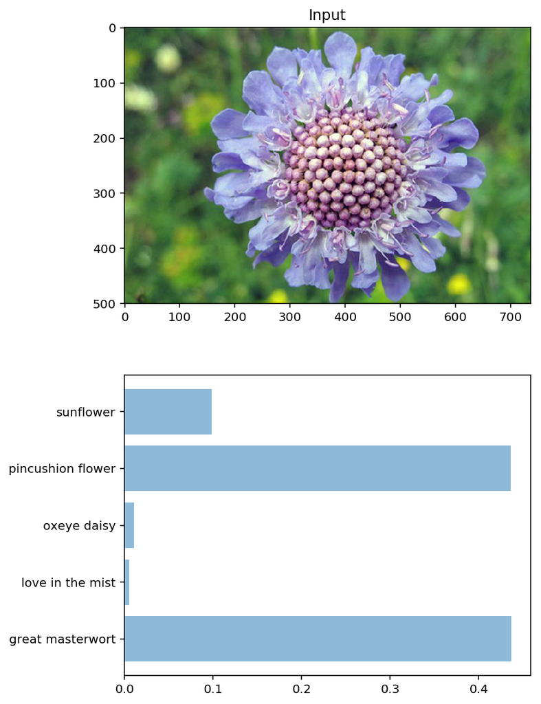

```python
# More testing
# Pretty bad distinguishing between Pincushion Flower and Great Masterwort.
# However, a quick google search made me realize that they are also
# non distinguishable to someone who does not know anything about flowers.

input_image3_path = os.path.join(data_dir, 'test/22/image_05366.jpg')
plot_topk(input_image3_path, loaded_model)
```